# Final Project LOL

## Refined Model

Let’s now remove the high neff ratio terms from the extended model (i.e. > 1) and include the interaction terms we deemed useful beforehand

```r
ext_main_int <- stan_glm(gameDuration ~ firstDragon + firstBaron + t1_baronKills + t1_dragonKills + t2_baronKills + t2_dragonKills + t1_baronKills:t2_baronKills + t1_dragonKills:t2_dragonKills,
  data = lol_data, family = gaussian,
  prior_intercept = normal(1800, 150, autoscale = TRUE),
  prior = normal(0, 2.5, autoscale = TRUE),
  prior_aux = exponential(1, autoscale = TRUE),
  chains = 4, iter = 5000*2, seed = 84735)
```

```r
prior_summary(ext_main_int)
```

```
Priors for model 'ext_main_int'
------
Intercept (after predictors centered)
  Specified prior:
    ~ normal(location = 1800, scale = 150)
  Adjusted prior:
    ~ normal(location = 1800, scale = 64093)

Coefficients
  Specified prior:
    ~ normal(location = [0,0,0,...], scale = [2.5,2.5,2.5,...])
  Adjusted prior:
    ~ normal(location = [0,0,0,...], scale = [2136.66,2136.42,2289.92,...])

Auxiliary (sigma)
  Specified prior:
    ~ exponential(rate = 1)
  Adjusted prior:
    ~ exponential(rate = 0.0023)
------
See help('prior_summary.stanreg') for more details
```

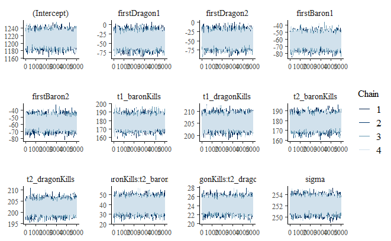

```r
mcmc_trace(ext_main_int, size = .1)
```

So far so good

```r
rhat(ext_main_int)
```

```
                  (Intercept)                  firstDragon1
                    1.0003440                     1.0003428
                 firstDragon2                   firstBaron1
                    1.0003775                     1.0000760
                  firstBaron2                 t1_baronKills
                    1.0002465                     1.0000761
               t1_dragonKills                 t2_baronKills
                    0.9998796                     1.0002153
               t2_dragonKills   t1_baronKills:t2_baronKills
                    0.9999051                     1.0002525
t1_dragonKills:t2_dragonKills                         sigma
                    1.0000077                     1.0000297
```

Rhat looks satisfactory for all predictors

```r
neff_ratio(ext_main_int)
```

```
                  (Intercept)                  firstDragon1
                      0.58795                       0.50540
                 firstDragon2                   firstBaron1
                      0.50105                       0.56190
                  firstBaron2                 t1_baronKills
                      0.53910                       0.53865
               t1_dragonKills                 t2_baronKills
                      0.67185                       0.53005
               t2_dragonKills   t1_baronKills:t2_baronKills
                      0.67705                       0.66965
t1_dragonKills:t2_dragonKills                         sigma
                      0.82210                       1.12835
```

```r
tidy(ext_main_int, effects = c("fixed", "aux"),
     conf.int = TRUE, conf.level = 0.95)
```

| term | estimate | std.error | conf.low | conf.high |
| --- | --- | --- | --- | --- |
| (Intercept) | 1210.53489 | 12.1769191 | 1186.83373 | 1234.31401 |
| firstDragon1 | -41.15022 | 12.9973747 | -66.16623 | -15.76198 |
| firstDragon2 | -45.53698 | 13.0012329 | -70.57310 | -20.28175 |
| firstBaron1 | -62.27498 | 6.1501923 | -74.19248 | -50.18130 |
| firstBaron2 | -58.23010 | 5.8076254 | -69.62075 | -46.90163 |
| t1_baronKills | 178.17458 | 4.8625529 | 168.49350 | 187.56663 |
| t1_dragonKills | 205.49679 | 1.8451560 | 201.94598 | 209.04666 |
| t2_baronKills | 178.45413 | 4.5639175 | 169.61507 | 187.44408 |
| t2_dragonKills | 202.14295 | 1.8343481 | 198.55376 | 205.74762 |
| t1_baronKills:t2_baronKills | 39.32916 | 4.5235930 | 30.53662 | 48.15511 |

[output cut: 3 more lines]

Every value looks significant from the 95% CI (even the interaction terms!!) due to none of them including 0.

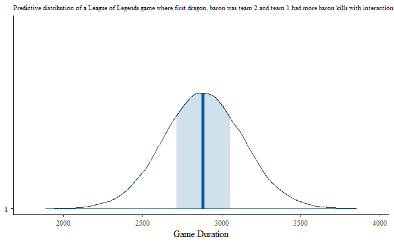

```r
# dataframe with the specified values
newdata_ext_int <- data.frame(
  firstDragon = factor(2, levels = levels(lol_data$firstDragon)),
  firstBaron = factor(2, levels = levels(lol_data$firstBaron)),
  t1_baronKills = 2,
  t1_dragonKills = 2,
  t2_baronKills = 1,
  t2_dragonKills = 3
)

ext_main_int_predict <- posterior_predict(ext_main_int, newdata = newdata_ext_int)

mcmc_areas(ext_main_int_predict) +
  xlab("Game Duration") +
  ggtitle('Predictive distribution of a League of Legends game where first dragon, baron was team 2 and team 1 had more baron kills with interaction') +
  theme(plot.title = element_text(size = 8))
```

The games seem to drag on even longer with this new model. This is expected since the dragon and baron respawn times are quite long so, as said before, the comeback would realistically take longer than average.

Lets do some model comparisons to verify which model is best

## Model Comparisons

### PP Check

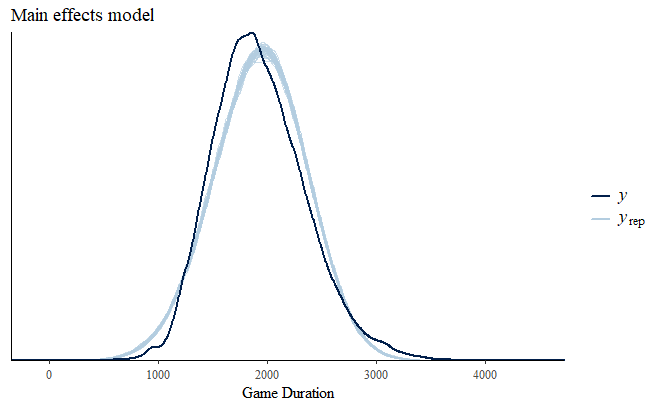

```r
pp_check(main, nreps = 50) + xlab("Game Duration") +
  ggtitle('Main effects model')
```

The main model gets a decent amount of area, yet it starts moving too far right and undershoots at the peak

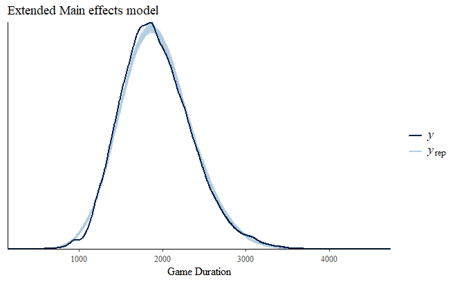

```r
pp_check(ext_main, nreps = 50) + xlab("Game Duration") +
  ggtitle('Extended Main effects model')
```

The extended model is objectively better than the main model, but still undershoots area at the peak

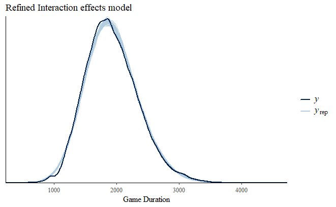

```r
pp_check(ext_main_int, nreps = 50) + xlab("Game Duration") +
  ggtitle('Refined Interaction effects model')
```

The interaction model is very similar to the extended model which is better than the main model.

The ppchecks show most of the are being covered for the last 2 models with the interaction model doing better around the peak by a small margin

### 10 Fold Cross-Validations

```r
test_sample <- lol_data %>% head(10000)
nrow(test_sample)
```

```
[1] 10000
```

```r
set.seed(84735)

p_main <- prediction_summary(model = main, data = test_sample)
p_ext_main <- prediction_summary(model = ext_main, data = test_sample)
p_ext_main_int <- prediction_summary(model = ext_main_int, data = test_sample)
```

```r
rbind(p_main, p_ext_main, p_ext_main_int)
```

| mae | mae_scaled | within_50 | within_95 |
| --- | --- | --- | --- |
| 255.6851 | 0.6784996 | 0.4974 | 0.9609 |
| 149.6301 | 0.6522156 | 0.5142 | 0.9514 |
| 166.5749 | 0.6602105 | 0.5099 | 0.9554 |

These are the raw MAE values based on a sample of 10000 observations from the data, we can use these to determine the behavior and bias of each model based on their cross-validation results

```r
set.seed(84735)

cv_main <- prediction_summary_cv(
  model = main, data = lol_data, k = 10)
```

```r
rbind(cv_main$cv, cv_extend$cv, cv_interact$cv)
```

| mae | mae_scaled | within_50 | within_95 |
| --- | --- | --- | --- |
| 255.8624 | 0.6787885 | 0.4971249 | 0.9586412 |
| 150.2308 | 0.6559153 | 0.5124297 | 0.9516519 |
| 166.2608 | 0.6589512 | 0.5095544 | 0.9526031 |

### Loo Diagnostics

```r
set.seed(34521)
main_elpd <- loo(main)
ext_main_elpd <- loo(ext_main)
ext_main_interact_elpd <- loo(ext_main_int)

main_elpd$estimates
```

```
              Estimate          SE
elpd_loo -3.323804e+05 174.6839030
p_loo     9.093789e+00   0.1196568
looic     6.647608e+05 349.3678059
```

```r
ext_main_elpd$estimates
```

```
             Estimate          SE
elpd_loo -309859.5959 173.9985196
p_loo         19.2336   0.2843918
looic     619719.1918 347.9970392
```

```r
ext_main_interact_elpd$estimates
```

```
              Estimate          SE
elpd_loo -314197.32595 179.0596124
p_loo         13.56236   0.2282117
looic     628394.65191 358.1192249
```

```r
c(main_elpd$estimates[1], ext_main_elpd$estimates[1], ext_main_interact_elpd$estimates[1])
```

```
[1] -332380.4 -309859.6 -314197.3
```

```r
loo_compare(main_elpd, ext_main_elpd, ext_main_interact_elpd)
```

```
             elpd_diff se_diff
ext_main          0.0       0.0
ext_main_int  -4337.7      96.8
main         -22520.8     178.3
```

The extended model fairs better than the interaction model when comparing their ELPD and MAE. The interaction model does 4337.6 points “worse” for ELPD and is around 16 points higher in its MAE. However, something to consider here is the idea of [overfitting](https://statisticsbyjim.com/regression/overfitting-regression-models/) and how more predictors and affect the model overall and skew our metrics.

Despite the interaction model covering more area, the [MAE](https://stephenallwright.com/good-mae-score/) and ELPD are both worse. This may be due to these values being inflated by the larger number of predictors in the extended model. Furthermore, the extended model contains numerous values with higher than normal Neff Ratios which is a [cause for concern](https://stats.stackexchange.com/questions/296059/effective-sample-size-greater-than-actual-sample-size) about the validity of the model along with predictors that were not significant.

Despite having less predictors, the interaction model garners more area in its predictive posterior distribution while having a similar MAE and good ELPD score too (-309859.7 vs 314197.3) which is a minor (~1%) difference given the size of these values. However, these interaction terms could also be having an adverse effect on the model leading to these greater errors.

### Overfitting

```r
rbind(p_main, p_ext_main, p_ext_main_int)
```

| mae | mae_scaled | within_50 | within_95 |
| --- | --- | --- | --- |
| 255.6851 | 0.6784996 | 0.4974 | 0.9609 |
| 149.6301 | 0.6522156 | 0.5142 | 0.9514 |
| 166.5749 | 0.6602105 | 0.5099 | 0.9554 |

```r
rbind(cv_main$cv, cv_extend$cv, cv_interact$cv)
```

| mae | mae_scaled | within_50 | within_95 |
| --- | --- | --- | --- |
| 255.8624 | 0.6787885 | 0.4971249 | 0.9586412 |
| 150.2308 | 0.6559153 | 0.5124297 | 0.9516519 |
| 166.2608 | 0.6589512 | 0.5095544 | 0.9526031 |

Based on the difference between the raw MAE values and the cross-validation MAE values, overfitting does not seem to pose a threat to these models, however we can only truly know this if we are given new data entirely to test the models. Furthermore, the extended model does have a larger (though mostly negligible due to how small it is) difference from the cross-validation MAE compared to the other models.

## Regression Inference

Let’s see how the 2 best models fair when conducting a quick hypothesis test to see the Posterior probability of a game around 40 minutes long

We’ll use the predictive posterior models we created and visualized earlier to conduct the tests

$$H_0: \pi \geq 2500$$

$$H_a: \pi < 2500$$

```r
# Extract the posterior samples
posterior_samples <- ext_main_int_predict

p_H0 <- mean(posterior_samples >= 2500)

p_Ha <- mean(posterior_samples < 2500)

# Print the results
cat("Posterior probability of H0 (π ≥ 2500):", p_H0)
```

```
Posterior probability of H0 (π ≥ 2500): 0.9364
```

```r
cat("Posterior probability of Ha (π < 2500):", p_Ha)
```

```
Posterior probability of Ha (π < 2500): 0.0636
```

```r
# Extract the posterior samples
posterior_samples <- ext_main_predict

p_H0 <- mean(posterior_samples >= 2500)

p_Ha <- mean(posterior_samples < 2500)

# Print the results
cat("Posterior probability of H0 (π ≥ 2500):", p_H0)
```

```
Posterior probability of H0 (π ≥ 2500): 0.42085
```

```r
cat("Posterior probability of Ha (π < 2500):", p_Ha)
```

```
Posterior probability of Ha (π < 2500): 0.57915
```

Though the two models seemingly predict the actual distribution of the data well, the 2 models have very different outcomes when conducting the test.

The extended model favors the alternate hypothesis while the interaction model clearly favors the null hypothesis. This both coincides with what we saw before from the visualizations and tells us that the extended model favors games that are shorter while the interaction model expects games like this to take longer.

This is also something one should consider when choosing the model. Whether or not the predictions themselves seem realistic given the scenario/circumstances.

To back up what I’m saying, Baron Nashor spawns at 20 minutes and respawns every 6 minutes. Since 3 Barons are killed in both scenarios, the game would have to be at least 38 minutes and only if the teams kill the Baron IMMEDIATELY (which is usually never the case). Therefore, one would expect majority of the area to lie within the ~40 minute range at the very least for when the game would end.

## Conclusion

In conclusion, it is a choice between whether one wants to take the chance of playing with a model that may be susceptible to overfitting for the sake of potentially less error or a slightly higher error model that has interactions but would be less likely to be susceptible to overfitting.

Personally, I say that the refined interaction model is the best model to use for predicting the game duration of a LOL match given our data due to its comparable MAE along with better posterior predictive abilities and lack of evidence for overfitting. Furthermore, based on my experience and game rules, the predictive values it comes up with end up being much more realistic in the grand scheme of things and with other factors such as respawn time considered.

## References

- https://www.bayesrulesbook.com/
- https://stats.stackexchange.com/questions/296059/effective-sample-size-greater-than-actual-sample-size
- https://stephenallwright.com/good-mae-score/
- https://discourse.mc-stan.org/t/understanding-looic/13409/6
- https://discourse.mc-stan.org/t/projpred-elpd-goes-down-and-rmse-goes-up-after-x-variables/13153
- https://stats.stackexchange.com/questions/313564/how-does-bayesian-analysis-make-accurate-predictions-using-subjectively-chosen-p
- https://medium.com/@ooemma83/interpretation-of-evaluation-metrics-for-regression-analysis-mae-mse-rmse-mape-r-squared-and-5693b61a9833
- https://statisticsbyjim.com/regression/overfitting-regression-models/
- https://stats.stackexchange.com/questions/9053/how-does-cross-validation-overcome-the-overfitting-problem

## Honor Pledge

On my honor, I have neither received nor given any unauthorized assistance on this project

Signed: Thomas Christo (tjc260)